05 · WALL FILM

# Wall-film behaviour

6.69 → 9.54 kgearly-run film mass · 265 → 500 ms

Wall liquid can spread, drain or return to the steam as droplets. Different runs reveal these different parts of its behaviour.

## 1 · Film spreads and stores liquid

Early runs showed a broader, thicker film over the lower and middle walls. The upper wall remained thinner.

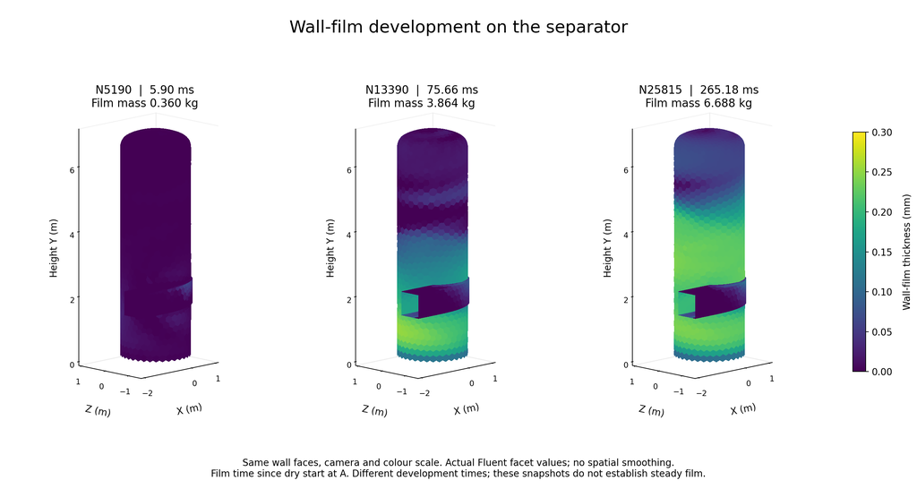

Same camera and 0–0.30 mm scale. These early snapshots have release models OFF; the rate history continues to 500 ms.

## 2 · Added models represent liquid returning to the flow

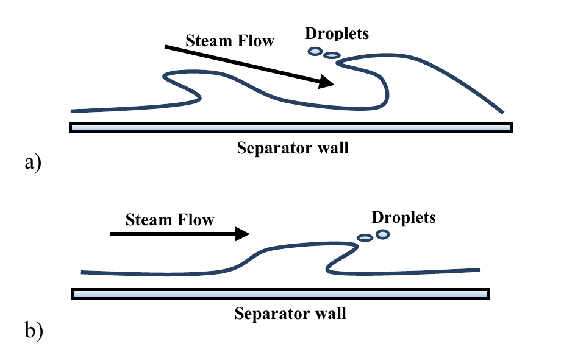

Steam removes droplets from film waves.  
Rizaldy et al. (2016), Fig. 9, after Ishii & Grolmes (1975).

**Stripping:** steam shear removes film droplets. The literature sketch gives the physical rationale.

**Splashing:** droplet impacts create more droplets. Added as a separate impact model.

**Edge separation:** film leaves wall edges as droplets. Added as a separate edge model.

Later runs enabled these processes and droplet collection. They add liquid-transfer paths; they do not resolve every breakup event.

## 3 · Rates distinguish drainage, release and accumulation

Early run · input, drainage and storage

At 500 ms: 81.12 in · 69.60 drained · 11.53 stored kg/s

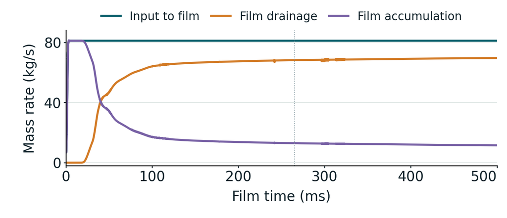

Input exceeded drainage; film mass continued to rise.  
Endpoint numbers are final-10-ms means.

Later run · release plus film absorber

Mean rates in a 75 ms window before the numerical guard.

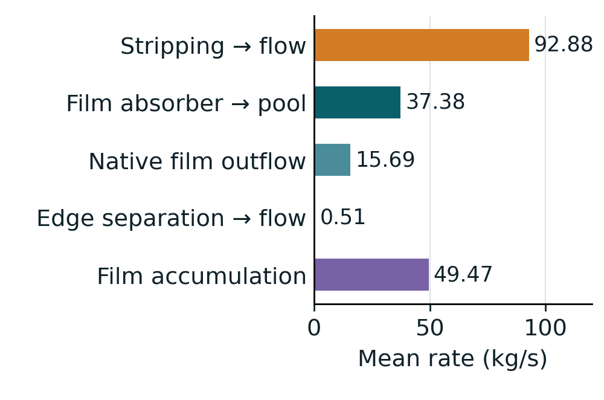

Stripping and edge separation transfer liquid to the flow. The film absorber removes mass and momentum to represent entry into the brine pool. No isolated splash rate was recorded.

**What we learnt:** active lower-film removal can coexist with continued upper-film accumulation. Film growth, drainage and droplet release must be assessed together.

Two different model-development runs; bulk flow was frozen during these film windows. Steady film was not reached. The later run stopped at a numerical guard and retains source-accounting and inner-solve limits; its transfer rates do not establish separator efficiency.

**Evidence and figure sources**

The early figure shows the selected Stage 3 field history. Its 500 ms result continues the same 265 ms parent; stripping, splashing, edge separation and DPM collection were OFF. The later Stage 4 run uses a different developed parent, enabled particle/film transfers and direct lower-film removal. These are distinct model-development runs.

- Early film development and spatial evidence.
- 265 → 500 ms continuation lineage and 500 ms results.
- Early raw selected film history; no smoothing. The dotted line marks the final spatial snapshot at 265.18 ms; the rate history continues to 500 ms.
- Rizaldy et al. (2016), Fig. 9, PDF p.5, after Ishii and Grolmes (1975): undercut and roll-wave re-entrainment. Supports stripping rationale, not impact splashing or sharp-edge departure.
- [Fluent 2025 R2 theory: particle-wall interaction, film separation, stripping and phase accretion](https://ansyshelp.ansys.com/public/Views/Secured/corp/v252/en/flu_th/flu_th_ewf_sec_film_submodels.html). These submodels approximate transfers; the poster does not claim resolved wave breakup or physical validation.
- Later film-absorber and release-model run. The displayed means use N62647–N67647, +317.46–392.46 ms after this run's parent, a 75 ms window before the first Courant guard crossing. Native cumulative transfer differences are divided by accepted film time; direct drain is integrated from its recorded preceding rate. Splashing has no isolated reported mass rate.
- Later window evidence; the completed run was numerically rejected, with unresolved source accounting and no inner-residual qualification. Bars are descriptive film transfers, not a closed separator mass balance.

Figure provenance · PNG export